title: “Modeling and prediction for movies” output: html_document: fig_height: 4 highlight: pygments theme: spacelab —

## Setup

```r
library(ggplot2)
library(dplyr)
library(statsr)
```

### Load data

```r
load(file.choose())
```

## Part 1: Data

The data is a recollection from 651 random sampled movies that were filmed and released before 2016. This limits the scope of the research to an observational study were no causality can be inferred. Also the results may not be generalizable to audiences beyond those that visit pages like Rotten Tomatoes (critics and audience). Further, generalizability also gets hurt from the fact that may only include movies that are suitable for western societies.

## Part 2: Research question

Is there a relationship between the rating at audience score on Rotten Tomatoes (audience_score) the genre (genre), the duration of the movie (runtime), critics score (critics_score), and the rating of the movie (mpaa_rating).

In a nutshell, I would like to know if there is a relation between the above mentioned variables and the score in Rotten Tomatoes of the audience.

These questions are interesting since it would help use to make a sort of formula for getting the audience to the sack; for predicting the type of movies they tend to love and dislike.

## Part 3: Exploratory data analysis

First, we need to see the type of data we are working with

```r
str(movies)
```

```
## tibble [651 x 32] (S3: tbl_df/tbl/data.frame)
##  $ title           : chr [1:651] "Filly Brown" "The Dish" "Waiting for Guffman" "The Age of Innocence" ...
##  $ title_type      : Factor w/ 3 levels "Documentary",..: 2 2 2 2 2 1 2 2 1 2 ...
##  $ genre           : Factor w/ 11 levels "Action & Adventure",..: 6 6 4 6 7 5 6 6 5 6 ...
##  $ runtime         : num [1:651] 80 101 84 139 90 78 142 93 88 119 ...
##  $ mpaa_rating     : Factor w/ 6 levels "G","NC-17","PG",..: 5 4 5 3 5 6 4 5 6 6 ...
##  $ studio          : Factor w/ 211 levels "20th Century Fox",..: 91 202 167 34 13 163 147 118 88 84 ...
##  $ thtr_rel_year   : num [1:651] 2013 2001 1996 1993 2004 ...
##  $ thtr_rel_month  : num [1:651] 4 3 8 10 9 1 1 11 9 3 ...
##  $ thtr_rel_day    : num [1:651] 19 14 21 1 10 15 1 8 7 2 ...
##  $ dvd_rel_year    : num [1:651] 2013 2001 2001 2001 2005 ...
##  $ dvd_rel_month   : num [1:651] 7 8 8 11 4 4 2 3 1 8 ...
##  $ dvd_rel_day     : num [1:651] 30 28 21 6 19 20 18 2 21 14 ...
##  $ imdb_rating     : num [1:651] 5.5 7.3 7.6 7.2 5.1 7.8 7.2 5.5 7.5 6.6 ...
##  $ imdb_num_votes  : int [1:651] 899 12285 22381 35096 2386 333 5016 2272 880 12496 ...
```

[output cut: 18 more lines]

Therefore our variables of interest are: 1)runtime is numeric

2)genre with 11 levels (Action & Adventure, Comedy, Documentary, Drama, Horror, Mystery & Suspense, Other)

3)mpaa_rating with 6 levels

4)audience_score is numeric

5)critics_score is numeric

With this in mind we now can begin to graphic our variables

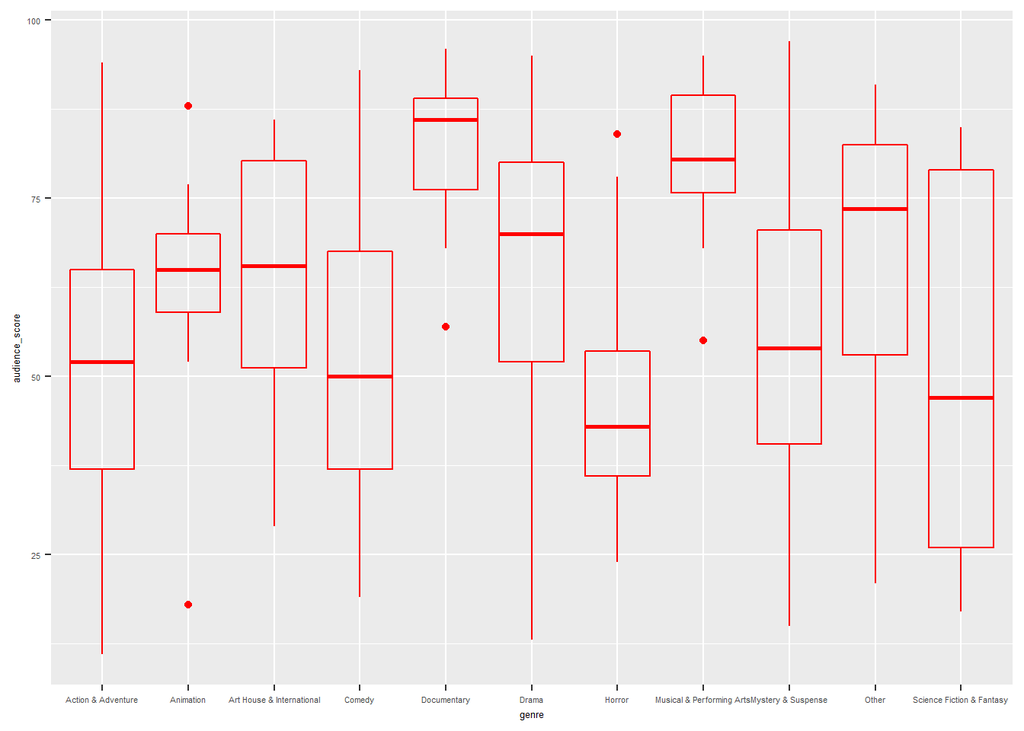

```r
#Genre
ggplot(data = movies, aes(x=genre, y=audience_score))+
  geom_boxplot(fill="transparent", color= "red", font= 1)+
  theme(text = element_text(size = 5))
```

With this we can appreciate that there are some genres that have better scores like: documentary or musical. There is also others that seem to be very volatile like science fiction were there are some very low and high scores. These scores seem to suggest that there are some genres that are a safer bet than others.

Now lets see if there is some relation between audience_score and thtr_rel_month

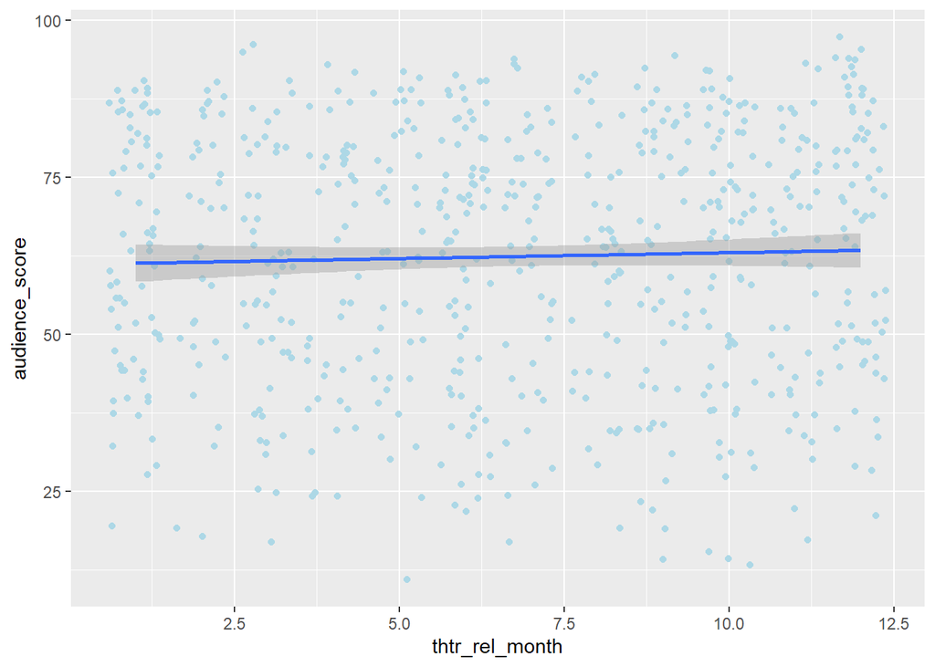

```r
ggplot(data = movies, aes(x=thtr_rel_month, y=audience_score))+
  geom_jitter(color= "light blue")+
   geom_smooth(method = "lm")
```

Unfortunately there seem to be no linear relation between thtr_rel_month and audience_score. Therefore is not a good variable for the model

Now lets see how does runtime and audience_score.

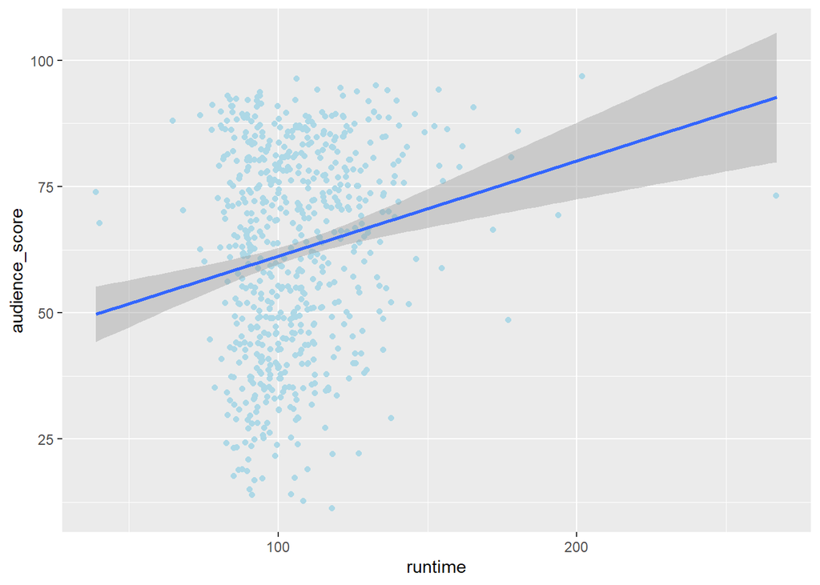

```r
ggplot(data = movies, aes(x=runtime, y=audience_score))+
  geom_jitter(color="light blue")+
  geom_smooth(method = "lm")
```

Again it seem that this are not good data since there are some extreme outliers that seem to affect the slope of the regression line. Still later analyses would tell.

Now lets check the relation between mpaa_rating and the audience_score

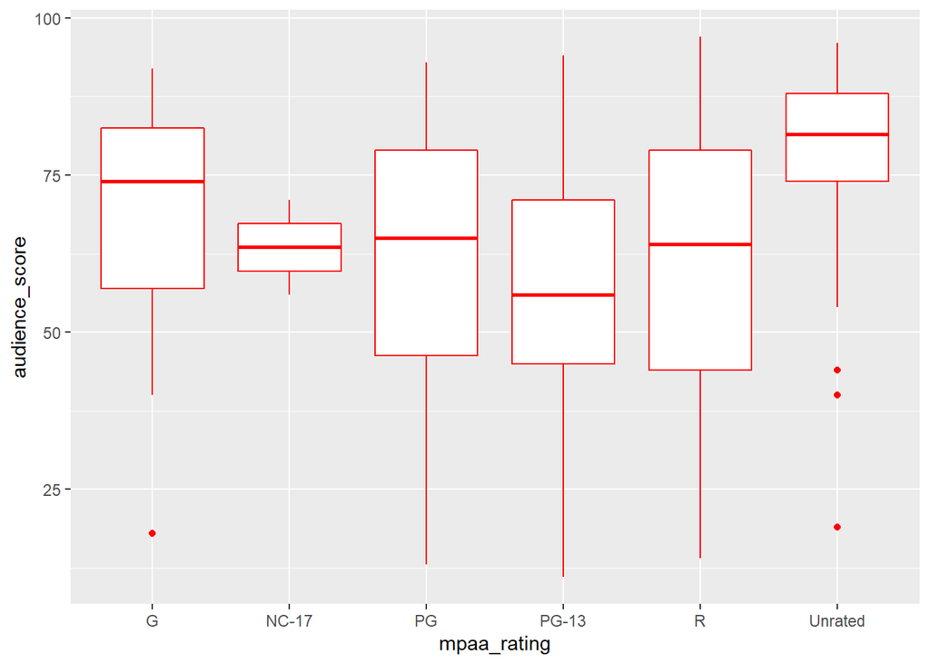

```r
ggplot(data=movies, aes(x=mpaa_rating, y=audience_score))+
  geom_boxplot(color= "red")
```

We can appreciate that the NC-17 (Adults Only) seem to be the less variable but also the ones with the least higher scores. This may because less people watch this movies. Also we can appreciate that the G (general audience movies) and the Unrated movies seem to be the ones with the better scores.

Finally, the relation between audience score and the critics score

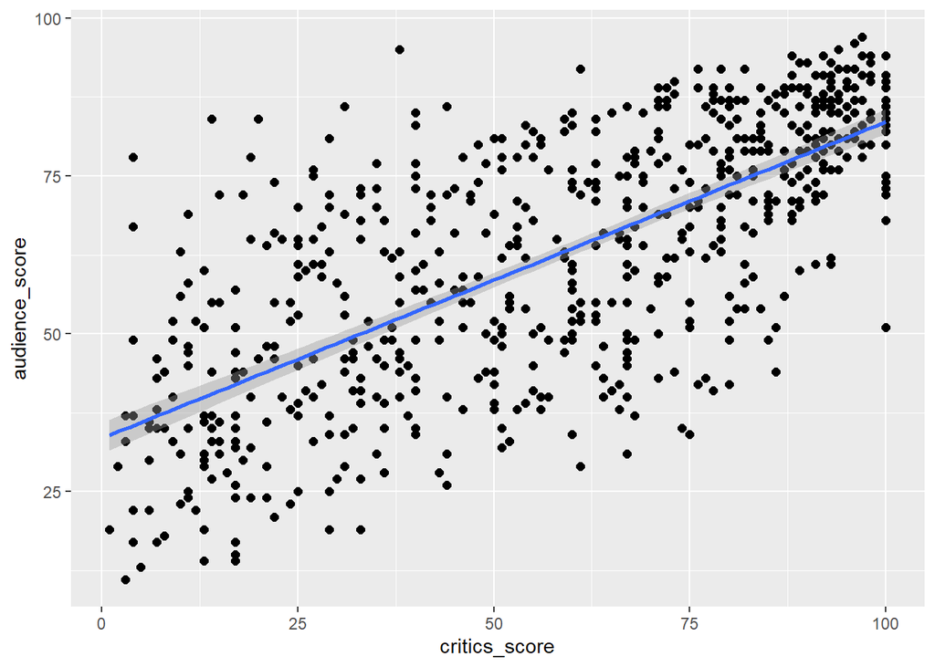

```r
ggplot(data=movies, aes(x=critics_score, y=audience_score))+
  geom_point(fill="light blue", size=2)+
  geom_smooth(method = "lm")
```

## Part 4: Modeling

Now lets begin with our model

```r
m1 <- lm(audience_score~ genre+ critics_score+ mpaa_rating, runtime, data=movies)
summary(m1)
```

```
##
## Call:
## lm(formula = audience_score ~ genre + critics_score + mpaa_rating,
##     data = movies, subset = runtime)
##
## Residuals:
##     Min      1Q  Median      3Q     Max
## -29.173 -10.151   1.212  10.696  42.136
##
## Coefficients:
##                                 Estimate Std. Error t value Pr(>|t|)
## (Intercept)                     17.56732    4.39756   3.995 7.23e-05 ***
## genreAnimation                  13.09666   14.30735   0.915  0.36034
## genreComedy                     10.19613    2.17259   4.693 3.30e-06 ***
## genreDocumentary                -2.28389    3.96582  -0.576  0.56489
## genreDrama                      -3.45747    1.98339  -1.743  0.08178 .
## genreHorror                    -27.89926    5.68896  -4.904 1.19e-06 ***
## genreMusical & Performing Arts -12.08121    5.58220  -2.164  0.03082 *
## genreMystery & Suspense        -10.99160    2.76117  -3.981 7.66e-05 ***
## genreOther                       6.98785    4.76832   1.465  0.14329
## critics_score                    0.59033    0.02255  26.183  < 2e-16 ***
## mpaa_ratingPG                   10.53784    4.86567   2.166  0.03070 *
## mpaa_ratingPG-13                 9.83651    4.91871   2.000  0.04594 *
## mpaa_ratingR                     9.46387    4.68392   2.021  0.04375 *
## mpaa_ratingUnrated              17.08997    5.46116   3.129  0.00183 **
## ---
## Signif. codes:  0 '***' 0.001 '**' 0.01 '*' 0.05 '.' 0.1 ' ' 1
##
## Residual standard error: 13.64 on 636 degrees of freedom
##   (1 observation deleted due to missingness)
## Multiple R-squared:  0.6273, Adjusted R-squared:  0.6197
## F-statistic: 82.36 on 13 and 636 DF,  p-value: < 2.2e-16
```

Let’s make some diagnostics

```r
#Without genre
m2 <- lm(audience_score~critics_score+ mpaa_rating +runtime, data=movies)
summary(m2)$adj.r.squared
```

```
## [1] 0.4985889
```

```r
#Without critics score
m2 <- lm(audience_score~genre+ mpaa_rating+runtime, data=movies)
summary(m2)$adj.r.squared
```

```
## [1] 0.2191459
```

```r
#Without mpaa
m2 <- lm(audience_score~genre+ critics_score+runtime, data=movies)
summary(m2)$adj.r.squared
```

```
## [1] 0.5234885
```

```r
#Without runtime
m2 <- lm(audience_score~genre+ critics_score+ mpaa_rating, data=movies)
summary(m2)$adj.r.squared
```

```
## [1] 0.5176312
```

In this model our coefficients mean that if X coefficient is the case then audience_score increases(or reduces) by X coefficient if, and only if, everything remains equal. Therefore coefficients effects are dependent on other coefficients for their particular relation to the outcome variable. Which is different from our normal linear regression where the relation is direct and independent.

Now let’s make some diagnostics for our m1

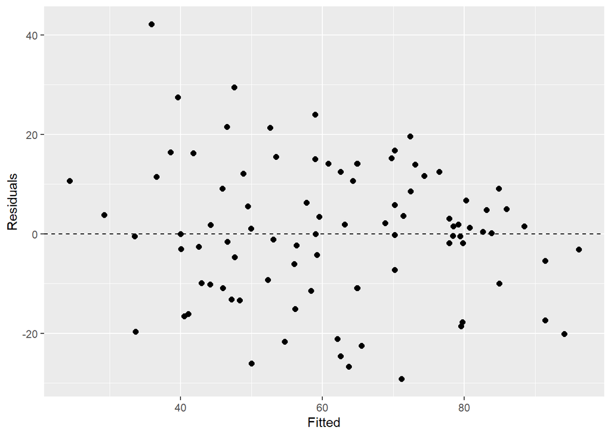

```r
#homeoscedasticity
ggplot(data=m1, aes(x=.fitted, y=.resid))+
  geom_jitter(size= 2)+
  geom_hline(yintercept = 0, linetype= "dashed")+
  xlab("Fitted")+
  ylab("Residuals")
```

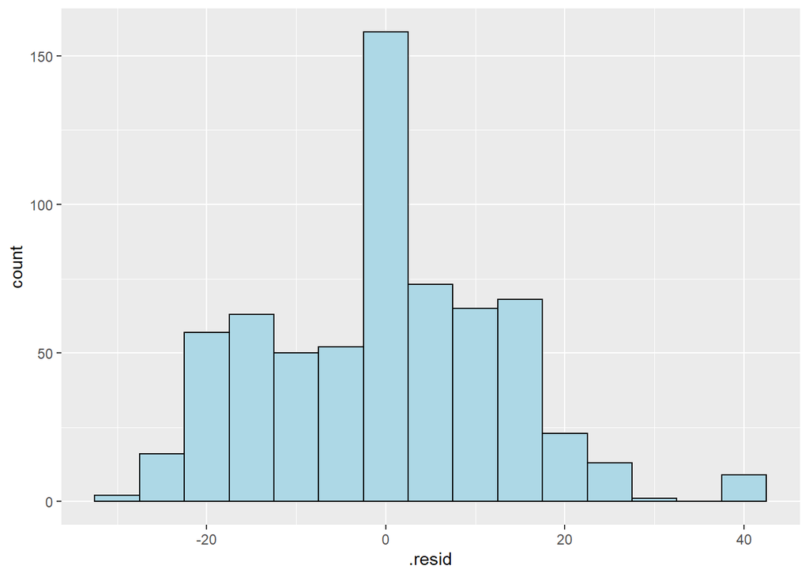

```r
#Residuals normality

ggplot(data = m1, aes(x=.resid))+
  geom_histogram(binwidth = 5, fill= "light blue", color= "black")
```

## Part 5: Prediction

Let’s be sure that this are legit values and that we are not extrapolating our data

```r
summary(movies$critics_score)
```

```
##    Min. 1st Qu.  Median    Mean 3rd Qu.    Max.
##    1.00   33.00   61.00   57.69   83.00  100.00
```

```r
summary(movies$runtime)
```

```
##    Min. 1st Qu.  Median    Mean 3rd Qu.    Max.    NA's
##    39.0    92.0   103.0   105.8   115.8   267.0       1
```

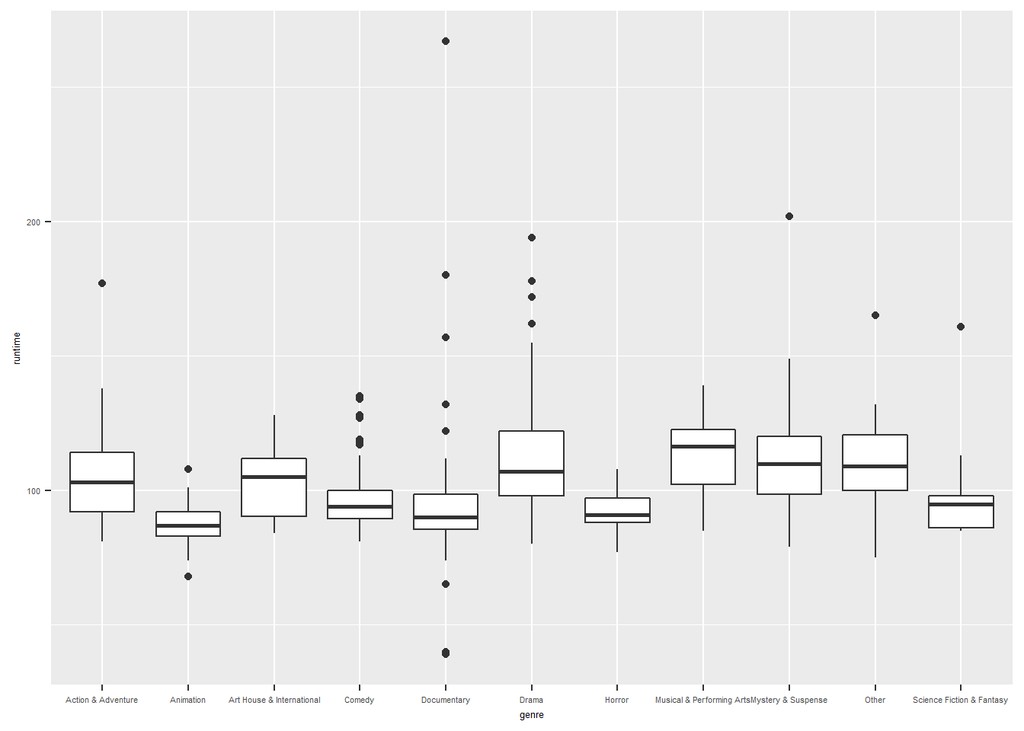

```r
ggplot(data=movies, aes(x=genre, y=runtime))+
  geom_boxplot()+
  theme(text = element_text(size = 5))
```

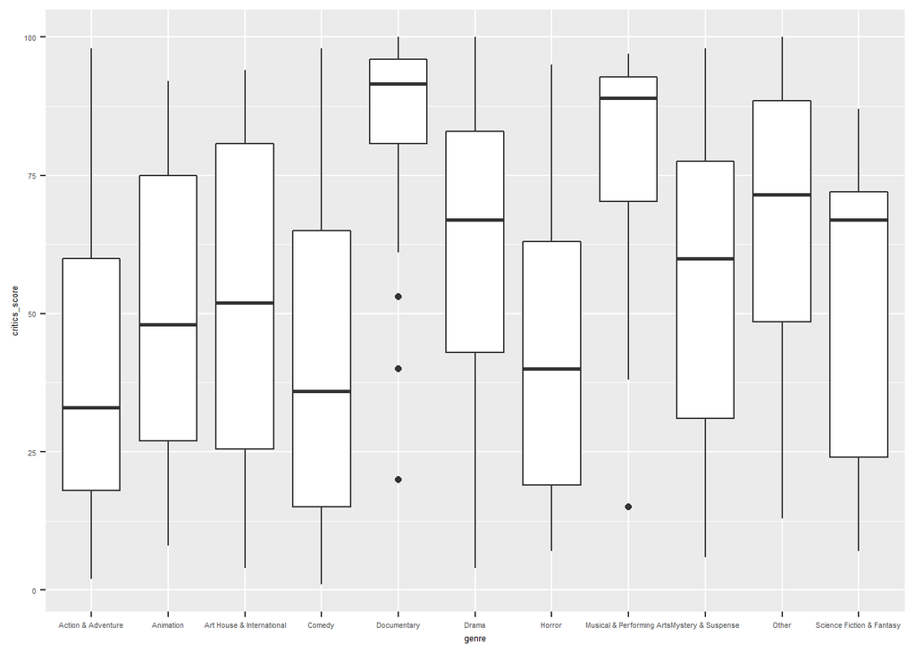

```r
ggplot(data = movies, aes(x=genre, y=critics_score))+
 geom_boxplot()+
  theme(text = element_text(size = 5))
```

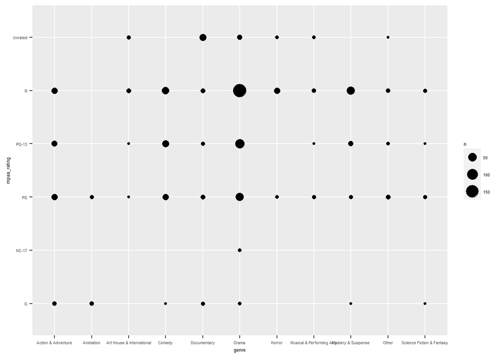

```r
ggplot(data = movies, aes(x=genre, y=mpaa_rating))+
  geom_count(fill= "light blue")+
  theme(text=element_text(size = 5))
```

```r
newmovie <- data.frame(genre = "Horror", critics_score = 70, runtime= 100, mpaa_rating= "R")

predict(m1, newmovie, interval = "prediction", level = 0.95)
```

```
##        fit      lwr      upr
## 1 40.45529 11.63625 69.27433
```